# 8. Worksheet: Among Site (Beta) Diversity – Part 1

Herbert Sizek; Z620: Quantitative Biodiversity, Indiana University

21 April, 2021

## OVERVIEW

In this worksheet, we move beyond the investigation of within-site $\alpha$-diversity. We will explore $\beta$-diversity, which is defined as the diversity that occurs among sites. This requires that we examine the compositional similarity of assemblages that vary in space or time.

After completing this exercise you will know how to:

1. formally quantify $\beta$-diversity
2. visualize $\beta$-diversity with heatmaps, cluster analysis, and ordination
3. test hypotheses about $\beta$-diversity using multivariate statistics

## Directions:

1. In the Markdown version of this document in your cloned repo, change “Student Name” on line 3 (above) with your name.
2. Complete as much of the worksheet as possible during class.
3. Use the handout as a guide; it contains a more complete description of data sets along with examples of proper scripting needed to carry out the exercises.
4. Answer questions in the worksheet. Space for your answers is provided in this document and is indicated by the “>” character. If you need a second paragraph be sure to start the first line with “>”. You should notice that the answer is highlighted in green by RStudio (color may vary if you changed the editor theme).
5. Before you leave the classroom today, it is *imperative* that you **push** this file to your GitHub repo, at whatever stage you are. Ths will enable you to pull your work onto your own computer.
6. When you have completed the worksheet, **Knit** the text and code into a single PDF file by pressing the `Knit` button in the RStudio scripting panel. This will save the PDF output in your ‘8.BetaDiversity’ folder.
7. After Knitting, please submit the worksheet by making a **push** to your GitHub repo and then create a **pull request** via GitHub. Your pull request should include this file (**8.BetaDiversity_1_Worksheet.Rmd**) with all code blocks filled out and questions answered) and the PDF output of `Knitr`  
   (**8.BetaDiversity_1_Worksheet.pdf**).

The completed exercise is due on **Friday, April 16<sup>th</sup>, 2021 before 09:00 AM**.

## 1) R SETUP

Typically, the first thing you will do in either an R script or an RMarkdown file is setup your environment. This includes things such as setting the working directory and loading any packages that you will need.

In the R code chunk below, provide the code to:

1. clear your R environment,
2. print your current working directory,

```r
rm(list=ls())
getwd()
```

```
## [1] "D:/GitHub/QB2021_Sizek/2.Worksheets/8.BetaDiversity"
```

```r
setwd("D:/GitHub/QB2021_Sizek/2.Worksheets/8.BetaDiversity")
```

3. set your working directory to your “*/8.BetaDiversity*” folder, and
4. load the `vegan` R package (be sure to install if needed).

```r
for (i  in c("vegan","ade4", "viridis", "gplots", "BiodiversityR", "indicspecies")){
  require(i,character.only=TRUE)
}
```

```
## BiodiversityR 2.12-3: Use command BiodiversityRGUI() to launch the Graphical User Interface;
## to see changes use BiodiversityRGUI(changeLog=TRUE, backward.compatibility.messages=TRUE)
```

## 2) LOADING DATA

### Load dataset

In the R code chunk below, do the following:

1. load the `doubs` dataset from the `ade4` package, and
2. explore the structure of the dataset.

```r
# note, pleae do not print the dataset when submitting

data(doubs)
summary(doubs)
```

```
##         Length Class      Mode
## env     11     data.frame list
## fish    27     data.frame list
## xy       2     data.frame list
## species  4     data.frame list
```

*Question 1*: Describe some of the attributes of the `doubs` dataset.

1. How many objects are in `doubs`? > *Answer 1a*: 4
2. How many fish species are there in the `doubs` dataset? > *Answer 1b*: 27
3. How many sites are in the `doubs` dataset? > *Answer 1c*: 30

### Visualizing the Doubs River Dataset

*Question 2*: Answer the following questions based on the spatial patterns of richness (i.e., $\alpha$-diversity) and Brown Trout (*Salmo trutta*) abundance in the Doubs River.

1. How does fish richness vary along the sampled reach of the Doubs River? > *Answer 2a*:

```r
S.obs <- function(x=''){
  rowSums(x>0)*1
}
cFisher <-function(x=''){
  fisher.alpha(as.integer(as.vector(x[x>0])))
}
S.obs(doubs$fish)
```

```
##  1  2  3  4  5  6  7  8  9 10 11 12 13 14 15 16 17 18 19 20 21 22 23 24 25 26
##  1  3  4  8 11 10  5  0  5  6  6  6  6 10 11 17 22 23 23 22 23 22  3  8  8 21
## 27 28 29 30
## 22 22 26 21
```

```r
apply(doubs$fish,1,cFisher)
```

```
##          1          2          3          4          5          6          7
##  0.5252543  1.2838726  1.7118462  4.7170847  5.6420718  7.4791167  2.4967465
##          8          9         10         11         12         13         14
##  1.0000000  2.7823859  3.9775884  5.4028053  3.1515726  3.0201644  5.5647670
##         15         16         17         18         19         20         21
##  5.7778860 11.1701802 17.5099120 20.8366287 18.3058149 13.3546197 13.2359384
##         22         23         24         25         26         27         28
## 10.8014143  5.4525555  6.9657122 13.1934641 16.2109829 12.0091137 11.0334863
##         29         30
## 12.5581380  8.6723803
```

> *Answer 2c*: There is spatial variation in richness across space, so if your habitat of interest is heterogeneous the samples might reflect the habitat health or some other variable rather than a large variation in species richness.

## 3) QUANTIFYING BETA-DIVERSITY

In the R code chunk below, do the following:

1. write a function (`beta.w()`) to calculate Whittaker’s $\beta$-diversity (i.e., $\beta_{w}$) that accepts a site-by-species matrix with optional arguments to specify pairwise turnover between two sites, and

```r
beta.w <- function(site.by.species = "",sitenum1="",sitenum2=""){
  if (sitenum1=="" | sitenum2==""){
    if (xor(sitenum1=="",sitenum2=="")){
      warning("beta.w: One site was specified, returning beta for entire SbyS matrix")
    }
    SbyS.pa <- decostand(site.by.species,method = "pa") # convert to presence absence
    S <- ncol(SbyS.pa[,which(colSums(SbyS.pa)>0)])
    a.bar<-mean(specnumber(SbyS.pa))
    b.w <-round(S/a.bar,3)
    return(b.w)
  }
  else{
    site1 = site.by.species[sitenum1,]
    site2 = site.by.species[sitenum2,]
    site1 = subset(site1, select = site1>0)
    site2 = subset(site2, select = site2>0)
    gamma = union(colnames(site1),colnames(site2))
    s = length(gamma)
    a.bar = mean(c(specnumber(site1),specnumber(site2)))
    b.w = round(s/a.bar -1,3)
    return(b.w)
  }

}
```

2. use this function to analyze various aspects of $\beta$-diversity in the Doubs River.

```r
beta.w(doubs$fish)
```

```
## [1] 2.16
```

```r
beta.w(doubs$fish,5,26)
```

```
## [1] 0.438
```

*Question 3*: Using your `beta.w()` function above, answer the following questions:

```r
S.obs(doubs$fish[c(1,2,10),])
```

```
##  1  2 10
##  1  3  6
```

```r
beta.w(doubs$fish,1,2)
```

```
## [1] 0.5
```

```r
beta.w(doubs$fish,1,10)
```

```
## [1] 0.714
```

> The species at site 1 is more similar to the species at site 2, but this is primarily driven by that site 2 has fewer species than site 10.
3. Using your understanding of the equation $\beta_{w} = \gamma/\alpha$, how would your interpretation of $\beta$ change if we instead defined beta additively (i.e., $\beta = \gamma - \alpha$)? > *Answer 3c*: This would make the measure a bit harder for me to understand value in as the number of sites would effect the outcome more. It would be more like a measure of the first moment of species. I don’t know really how I would apply it thoughtfully.

### The Resemblance Matrix

In order to quantify $\beta$-diversity for more than two samples, we need to introduce a new primary ecological data structure: the **Resemblance Matrix**.

*Question 4*: How do incidence- and abundance-based metrics differ in their treatment of rare species?

> *Answer 4*: Incidence matrices are binary matricies while abundance matrices are whole numbers. This means that rare species are of equal value in binary matrices while they are not in abundance matrices.

In the R code chunk below, do the following:

1. make a new object, `fish`, containing the fish abundance data for the Doubs River,
2. remove any sites where no fish were observed (i.e., rows with sum of zero),

```r
fish <- doubs$fish
fish<- fish[-which(rowSums(fish)==0),] #remove rows with zero values.
```

3. construct a resemblance matrix based on Sørensen’s Similarity (“fish.ds”), and

```r
fish.ds <- vegdist(fish,method="bray",binary=TRUE)
```

4. construct a resemblance matrix based on Bray-Curtis Distance (“fish.db”).

```r
fish.db <- vegdist(fish,method="bray")
```

*Question 5*: Using the distance matrices from above, answer the following questions:

1. Does the resemblance matrix (`fish.db`) represent similarity or dissimilarity? What information in the resemblance matrix led you to arrive at your answer? > *Answer 5a*: Dissimilarity is closer to 1, because the values close to the diagnal are near zero, while farther away (farther away sites) are near 1.

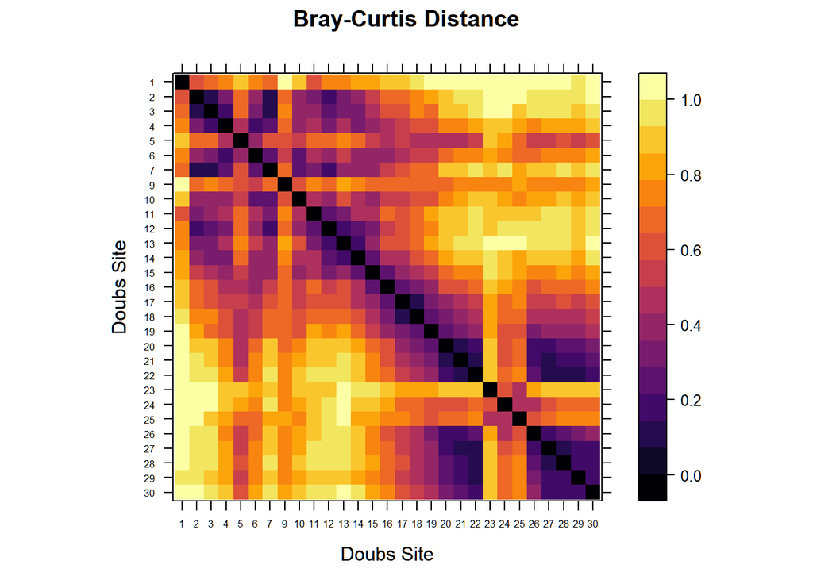

```r
order <- rev(attr(fish.db,"Labels"))
levelplot(as.matrix(fish.db)[,order],aspect="iso",col.regions=inferno,xlab="Doubs Site",ylab="Doubs Site", main="Bray-Curtis Distance",scales=list(cex=0.5))
```

2. Compare the resemblance matrices (`fish.db` or `fish.ds`) you just created. How does the choice of the Sørensen or Bray-Curtis distance influence your interpretation of site (dis)similarity?

> *Answer 5b*: They are fairly similar, Sorensen makes it seem that the sites are more homogenous then Bray-Curtis. Sorensen generally provides lower values (sites are more similar) in comparison to Bray-Curtis.

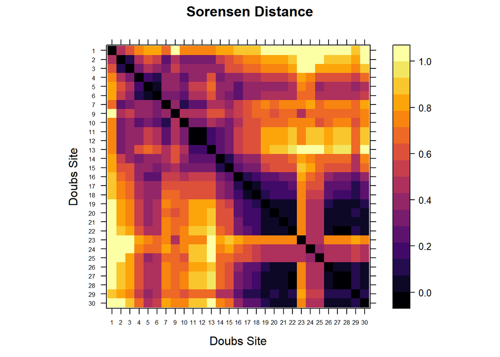

```r
order <- rev(attr(fish.ds,"Labels"))
levelplot(as.matrix(fish.ds)[,order],aspect="iso",col.regions=inferno,xlab="Doubs Site",ylab="Doubs Site", main="Sorensen Distance",scales=list(cex=0.5))
```

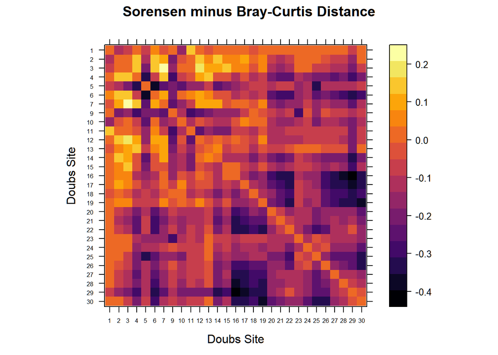

```r
order <- rev(attr(fish.ds-fish.db,"Labels"))
levelplot(as.matrix(fish.ds-fish.db)[,order],aspect="iso",col.regions=inferno,xlab="Doubs Site",ylab="Doubs Site", main="Sorensen minus Bray-Curtis Distance",scales=list(cex=0.5))
```

## 4) VISUALIZING BETA-DIVERSITY

### A. Heatmaps

In the R code chunk below, do the following:

1. define a color palette, > Viridis was imported above
2. define the order of sites in the Doubs River, and
3. use the `levelplot()` function to create a heatmap of fish abundances in the Doubs River.

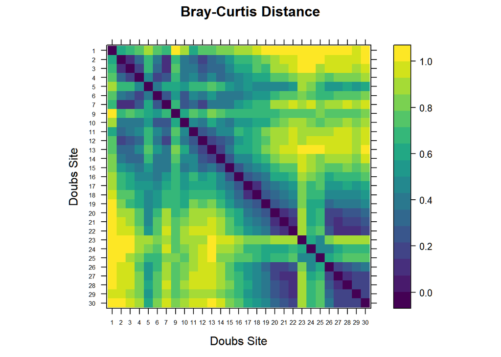

```r
order <- rev(attr(fish.db,"Labels"))
levelplot(as.matrix(fish.db)[,order],aspect="iso",col.regions=viridis,xlab="Doubs Site",ylab="Doubs Site", main="Bray-Curtis Distance",scales=list(cex=0.5))
```

### B. Cluster Analysis

In the R code chunk below, do the following:

1. perform a cluster analysis using Ward’s Clustering, and
2. plot your cluster analysis (use either `hclust` or `heatmap.2`).

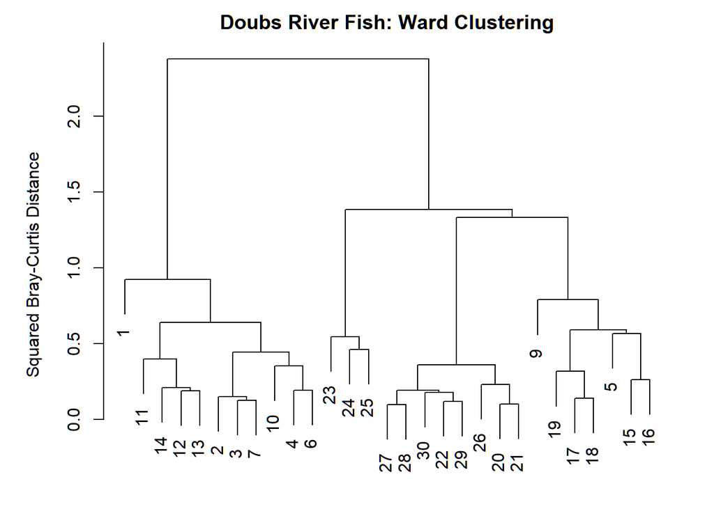

```r
fish.ward <- hclust(fish.db, method = "ward.D2")
par(mar = c(1,5,2,2)+0.1)
plot(fish.ward,main = "Doubs River Fish: Ward Clustering",ylab="Squared Bray-Curtis Distance")
```

### Principal Coordinates Analysis (PCoA)

In the R code chunk below, do the following:

1. perform a Principal Coordinates Analysis to visualize beta-diversity
2. calculate the variation explained by the first three axes in your ordination

```r
fish.pcoa <- cmdscale(fish.db, eig =TRUE, k=3)
var1 <- round(fish.pcoa$eig[1]/sum(fish.pcoa$eig),3)
var2 <- round(fish.pcoa$eig[2]/sum(fish.pcoa$eig),3)
var3 <- round(fish.pcoa$eig[3]/sum(fish.pcoa$eig),3)
sum.eig <- sum(var1,var2,var3)
```

3. plot the PCoA ordination,
4. label the sites as points using the Doubs River site number, and
5. identify influential species and add species coordinates to PCoA plot.

```r
fishREL <- fish
for (i in 1:nrow(fish)){
  fishREL[i,] = fish[i,]/sum(fish[i,])
}

fish.pcoa <-add.spec.scores(fish.pcoa,fishREL,method="pcoa.scores")
```

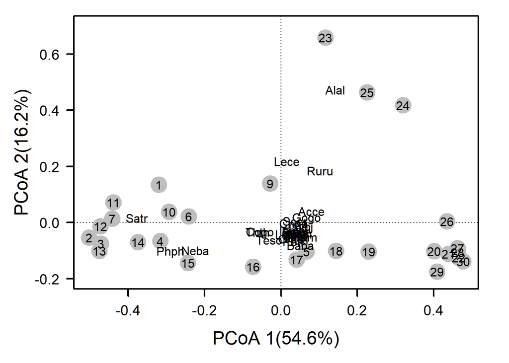

```r
par(mar=c(5,5,1,2)+0.1)
plot(fish.pcoa$points[,1],fish.pcoa$points[,2],ylim=c(-0.2,0.7),
     xlab = paste("PCoA 1(",var1*100,"%)",sep=''),
     ylab = paste("PCoA 2(",var2*100,"%)",sep=''),
     pch =16 ,cex =2.0,type ='n',cex.lab=1.5,cex.axis=1.2,axes=FALSE
     )

axis(side =1, labels=TRUE,lwd.ticks=2,cex.axis =1.2,las=1)
axis(side =2, labels=TRUE,lwd.ticks=2,cex.axis =1.2,las=1)
abline(h=0,v=0,lty=3)
box(lwd=2)
points(fish.pcoa$points[,1],fish.pcoa$points[,2],
       pch =19, cex =3, bg='gray',col='gray')
text(fish.pcoa$points[,1],fish.pcoa$points[,2],
     labels =row.names(fish.pcoa$points))

text(fish.pcoa$cproj[,1], fish.pcoa$cproj[,2], labels = row.names(fish.pcoa$cproj),col="black")
```

In the R code chunk below, do the following:

1. identify influential species based on correlations along each PCoA axis (use a cutoff of 0.70), and
2. use a permutation test (999 permutations) to test the correlations of each species along each axis.

```r
spe.corr <- add.spec.scores(fish.pcoa,fishREL,method = "cor.scores")$cproj
corr.cut <- 0.7
imp.spp <-spe.corr[abs(spe.corr[,1])>=corr.cut | abs(spe.corr[,2])>= corr.cut,]
fit <-envfit(fish.pcoa,fishREL,perm=999)
```

*Question 7*: Address the following questions about the ordination results of the `doubs` data set:

## SYNTHESIS

Using the `mobsim` package from the DataWrangling module last week, simulate two local communities each containing 1000 individuals (*N*) and 25 species (*S*), but with one having a random spatial distribution and the other having a patchy spatial distribution.

```r
require(mobsim)
comA <- sim_poisson_community(s_pool = 25, n_sim = 1000, sad_type = "lnorm",
        sad_coef = list("meanlog" = 2, "sdlog" = 1))

comB <- sim_thomas_community(s_pool = 25, n_sim = 1000, sad_type = "lnorm",
        sad_coef = list("meanlog" = 2, "sdlog" = 1))
```

Take ten (10) subsamples from each site using the quadrat function and answer the following questions:

```r
comm_matA <- sample_quadrats(comA, n_quadrats = 10, quadrat_area = 0.03,
             avoid_overlap = T, plot=F)
comm_matB <- sample_quadrats(comB, n_quadrats = 10, quadrat_area = 0.03,
             avoid_overlap = T, plot=F)
```

1. Compare the average pairwise similarity among subsamples in site 1 (random spatial distribution) to the average pairswise similarity among subsamples in site 2 (patchy spatial distribution).

```r
comA.ds <- vegdist(comm_matA$spec_dat,method="bray",binary=TRUE)
comB.ds <- vegdist(comm_matB$spec_dat,method="bray",binary=TRUE)
comA.db <- vegdist(comm_matA$spec_dat,method="bray")
comB.db <- vegdist(comm_matB$spec_dat,method="bray")
print(paste("Random Community's Average Similarity (Sorensen index):",mean(comA.ds)))
```

```
## [1] "Random Community's Average Similarity (Sorensen index): 0.202444742993374"
```

```r
print(paste("Patchy Community's Average Similarity (Sorensen index):",mean(comB.ds)))
```

```
## [1] "Patchy Community's Average Similarity (Sorensen index): 0.667763039429706"
```

Use a t-test to determine whether compositional similarity was affected by the spatial distribution. >First we need to look at if the t-test is appropriate in this case.

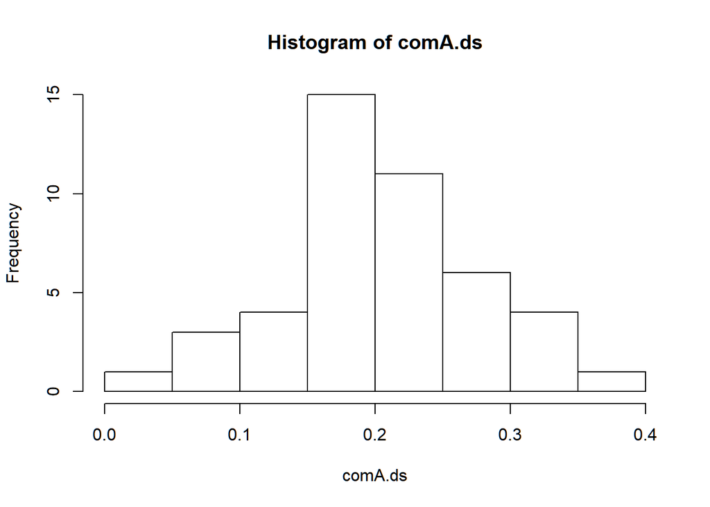

```r
hist(comA.ds,breaks=10)
```

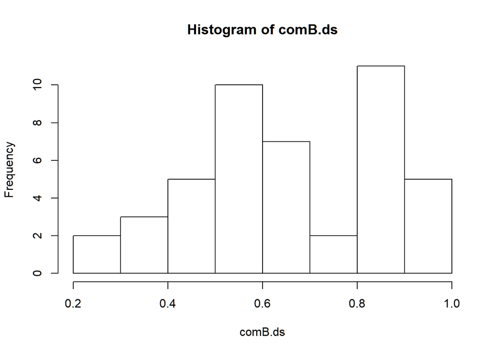

```r
hist(comB.ds,breaks=10)
```

> Doesn’t look like it from the historgrams because the limit of Sorensen index caps the values. To confirm, an F-test will do.

```r
var.test(comA.ds,comB.ds)
```

```
##
##  F test to compare two variances
##
## data:  comA.ds and comB.ds
## F = 0.15114, num df = 44, denom df = 44, p-value = 5.061e-09
## alternative hypothesis: true ratio of variances is not equal to 1
## 95 percent confidence interval:
##  0.0830551 0.2750231
## sample estimates:
## ratio of variances
##          0.1511359
```

> The F-test says that the variances between the datasets are different meaning that the t-test is not appropriate. Let’s repeat for BC index.

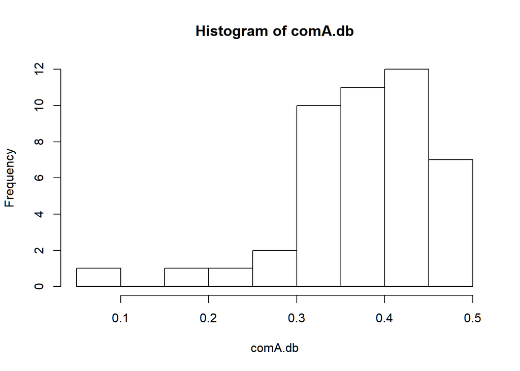

```r
hist(comA.db,breaks=10)
```

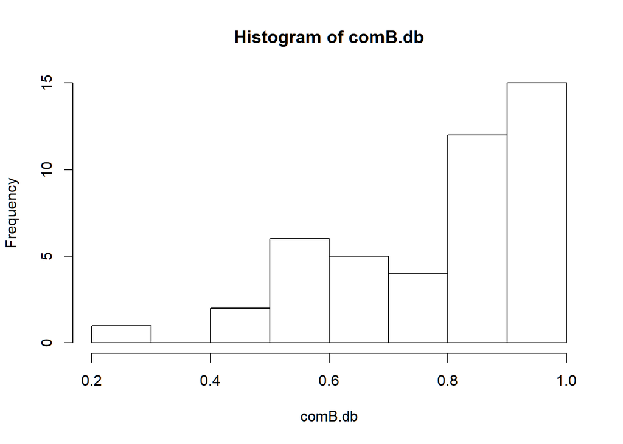

```r
hist(comB.db,breaks=10)
```

```r
var.test(comA.db,comB.db)
```

```
##
##  F test to compare two variances
##
## data:  comA.db and comB.db
## F = 0.19777, num df = 44, denom df = 44, p-value = 3.576e-07
## alternative hypothesis: true ratio of variances is not equal to 1
## 95 percent confidence interval:
##  0.1086831 0.3598861
## sample estimates:
## ratio of variances
##          0.1977714
```

> Again we see that the t-test is inappropriate. Probably some other test could be used but I don’t know frequentist statistics that well. From looking at the histograms, the pairwise comparisons look very different, with the clustered communities having more communities that are completely different from one another.

Finally, compare the compositional similarity of site 1 and site 2 to the source community?

```r
RACcomA <- rad.lognormal(comA$census)
```

```
## Error in y + 0.1 : non-numeric argument to binary operator
```

[figure not shown]

```r
plot(RACcomA, main = "Random community")
```

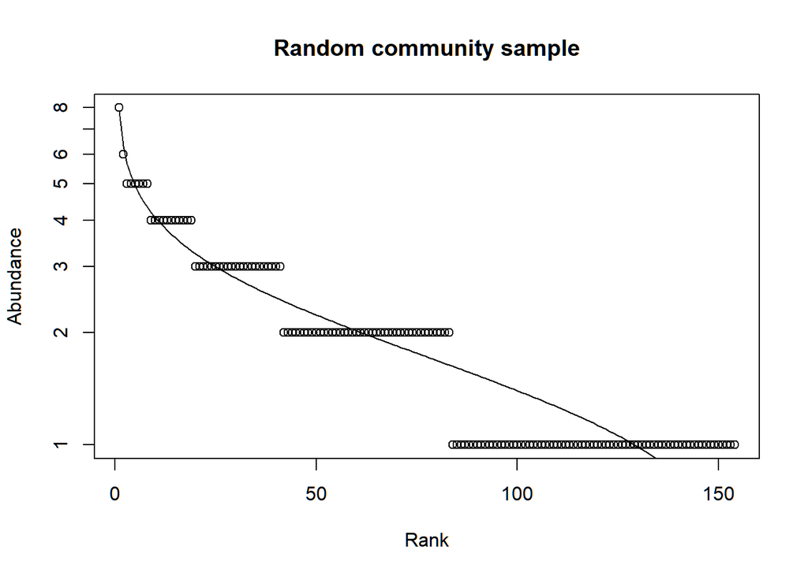

```r
RACcomAsample <- rad.lognormal(comm_matA$spec_dat)
plot(RACcomAsample, main = "Random community sample")
```

```r
RACcomB <- rad.lognormal(comB$census)
```

```
## Error in y + 0.1 : non-numeric argument to binary operator
```

[figure not shown]

```r
plot(RACcomB, main = "Clustered community")
```

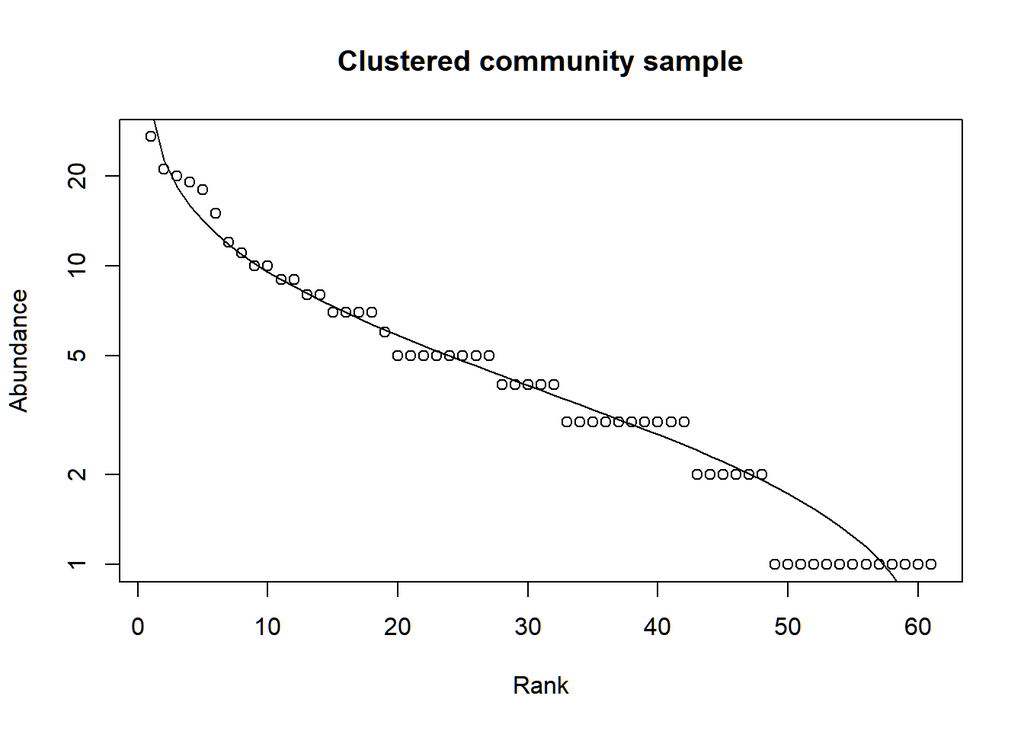

```r
RACcomBsample <- rad.lognormal(comm_matB$spec_dat)
plot(RACcomBsample, main = "Clustered community sample")
```

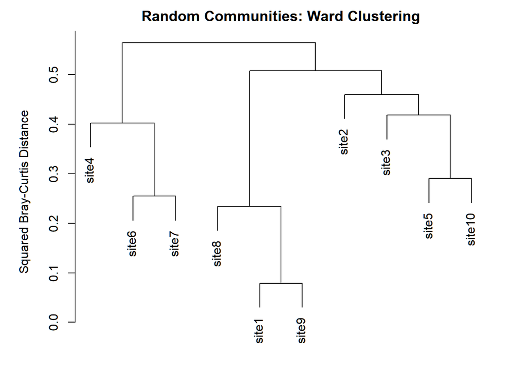

```r
comA.ward <- hclust(comA.db, method = "ward.D2")
par(mar = c(1,5,2,2)+0.1)
plot(comA.ward,main = "Random Communities: Ward Clustering",ylab="Squared Bray-Curtis Distance")
```

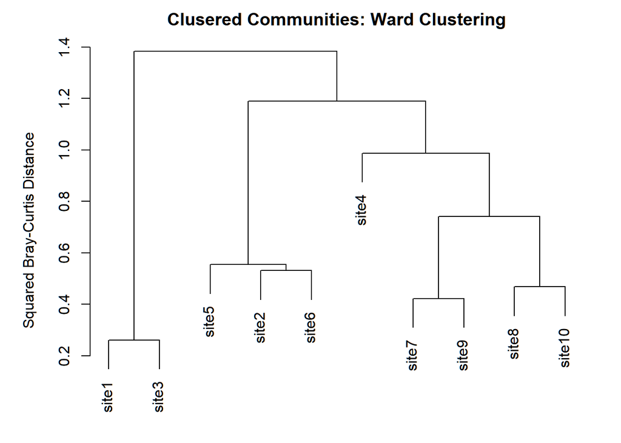

```r
comB.ward <- hclust(comB.db, method = "ward.D2")
par(mar = c(1,5,2,2)+0.1)
plot(comB.ward,main = "Clusered Communities: Ward Clustering",ylab="Squared Bray-Curtis Distance")
```

> We see that by looking at the axis values, that the clustered communities are farther apart from one another in composition than the random communities, though it does appear that we have some communities that are close to one another. It would probably be good to do other followup on this, such as does the BC distance correlate to other aspects, such as the Euclidian distance between sites.